# Glue and S3 parameters

```
Distribution of return_on_asset_cit, by year and indu_2
```

| year pct indu_2 | return_on_asset_cit 2004 0.25 | return_on_asset_cit 2004 0.5 | return_on_asset_cit 2004 0.75 | return_on_asset_cit 2004 0.95 | return_on_asset_cit 2004 0.99 | return_on_asset_cit 2005 0.25 | return_on_asset_cit 2005 0.5 | return_on_asset_cit 2005 0.75 | return_on_asset_cit 2005 0.95 | return_on_asset_cit 2005 0.99 | return_on_asset_cit 2006 0.25 | return_on_asset_cit 2006 0.5 | return_on_asset_cit 2006 0.75 | return_on_asset_cit 2006 0.95 | return_on_asset_cit 2006 0.99 | return_on_asset_cit 2007 0.25 | return_on_asset_cit 2007 0.5 | return_on_asset_cit 2007 0.75 | return_on_asset_cit 2007 0.95 | return_on_asset_cit 2007 0.99 |
| --- | --- | --- | --- | --- | --- | --- | --- | --- | --- | --- | --- | --- | --- | --- | --- | --- | --- | --- | --- | --- |
| 7 | 1.14 | 1.71 | 3.01 | 21.27 | 53.10 | 1.27 | 1.98 | 3.55 | 21.24 | 78.74 | 1.07 | 1.79 | 3.61 | 28.76 | 568.13 | 1.10 | 2.43 | 5.68 | 35.93 | 447.07 |
| 8 | 1.42 | 2.23 | 3.86 | 14.20 | 19.12 | 1.38 | 2.27 | 4.47 | 11.59 | 32.89 | 1.40 | 2.37 | 4.23 | 10.73 | 58.43 | 1.47 | 2.68 | 6.23 | 16.26 | 110.34 |
| 9 | 0.96 | 1.58 | 2.86 | 14.44 | 113.68 | 1.17 | 2.11 | 4.01 | 12.21 | 39.17 | 1.19 | 2.25 | 3.71 | 13.12 | 117.00 | 1.38 | 2.27 | 4.78 | 20.20 | 103.21 |
| 11 | 0.93 | 1.65 | 3.59 | 145.00 | 145.00 | 0.88 | 3.27 | 10.57 | 40.43 | 40.43 | 3.97 | 10.28 | 35.94 | 50.51 | 50.51 | 2.37 | 5.00 | 13.81 | 176.60 | 176.60 |
| 16 | 1.02 | 1.79 | 3.12 | 8.14 | 11.07 | 1.47 | 2.30 | 4.56 | 13.71 | 72.70 | 1.74 | 2.94 | 5.32 | 18.71 | 157.06 | 2.05 | 3.74 | 6.75 | 12.50 | 73.33 |
| 24 | 1.73 | 2.52 | 4.09 | 16.12 | 89.83 | 1.91 | 2.89 | 5.40 | 14.67 | 64.77 | 2.08 | 3.18 | 5.63 | 21.40 | 65.99 | 2.06 | 3.59 | 6.28 | 23.61 | 128.32 |
| 28 | 1.09 | 1.62 | 2.83 | 7.71 | 31.38 | 1.17 | 1.89 | 3.16 | 12.90 | 23.10 | 1.28 | 2.23 | 3.61 | 16.60 | 164.04 | 1.27 | 2.49 | 4.39 | 12.03 | 52.14 |
| 41 | 0.78 | 1.50 | 2.77 | 8.39 | 32.87 | 1.07 | 1.79 | 2.91 | 10.03 | 99.84 | 1.18 | 1.99 | 2.98 | 10.77 | 59.08 | 1.64 | 2.38 | 3.57 | 19.29 | 78.66 |
| 42 | 1.30 | 2.40 | 4.19 | 10.35 | 30.58 | 1.72 | 2.76 | 4.79 | 14.63 | 42.47 | 1.87 | 3.28 | 5.74 | 26.47 | 48.23 | 1.89 | 3.67 | 6.53 | 24.87 | 126.96 |
| 43 | 1.83 | 3.05 | 5.67 | 33.59 | 1,486.00 | 1.93 | 4.01 | 7.66 | 20.16 | 226.00 | 2.38 | 3.68 | 8.39 | 28.92 | 200.34 | 2.36 | 4.82 | 10.90 | 34.68 | 321.47 |

```
Distribution of return_on_asset_ci, by year and indu_2
```

| year pct indu_2 | return_on_asset_ci 2001 0.25 | return_on_asset_ci 2001 0.5 | return_on_asset_ci 2001 0.75 | return_on_asset_ci 2001 0.95 | return_on_asset_ci 2001 0.99 | return_on_asset_ci 2002 0.25 | return_on_asset_ci 2002 0.5 | return_on_asset_ci 2002 0.75 | return_on_asset_ci 2002 0.95 | return_on_asset_ci 2002 0.99 | return_on_asset_ci 2003 0.25 | return_on_asset_ci 2003 0.5 | return_on_asset_ci 2003 0.75 | return_on_asset_ci 2003 0.95 | return_on_asset_ci 2003 0.99 | return_on_asset_ci 2004 0.25 | return_on_asset_ci 2004 0.5 | return_on_asset_ci 2004 0.75 | return_on_asset_ci 2004 0.95 | return_on_asset_ci 2004 0.99 | return_on_asset_ci 2005 0.25 | return_on_asset_ci 2005 0.5 | return_on_asset_ci 2005 0.75 | return_on_asset_ci 2005 0.95 | return_on_asset_ci 2005 0.99 | return_on_asset_ci 2006 0.25 | return_on_asset_ci 2006 0.5 | return_on_asset_ci 2006 0.75 | return_on_asset_ci 2006 0.95 | … |
| --- | --- | --- | --- | --- | --- | --- | --- | --- | --- | --- | --- | --- | --- | --- | --- | --- | --- | --- | --- | --- | --- | --- | --- | --- | --- | --- | --- | --- | --- | --- |
| 7 | 1.26 | 1.70 | 2.79 | 21.25 | 45.99 | 0.00 | 0.00 | 0.00 | 0.00 | 0.00 | 1.31 | 2.12 | 3.10 | 21.25 | 45.99 | 1.28 | 2.12 | 3.63 | 28.79 | 45.99 | 1.26 | 1.84 | 3.10 | 22.41 | 45.99 | 1.26 | 1.74 | 3.10 | 22.41 | … |
| 9 | 1.20 | 1.85 | 3.31 | 11.57 | 176.89 | 0.00 | 0.00 | 0.00 | 0.00 | 0.00 | 1.12 | 1.87 | 3.42 | 12.87 | 115.24 | 1.06 | 1.87 | 3.54 | 12.87 | 115.24 | 1.10 | 1.88 | 3.42 | 11.79 | 27.40 | 1.06 | 1.88 | 3.54 | 12.87 | … |
| 11 | 0.56 | 4.45 | 4.47 | 77.90 | 77.90 | 0.00 | 0.00 | 0.00 | 0.00 | 0.00 | 0.56 | 1.36 | 1.36 | 1.36 | 1.36 | 1.08 | 2.10 | 4.47 | 77.90 | 77.90 | 0.87 | 2.10 | 10.57 | 77.90 | 77.90 | 1.36 | 4.47 | 40.43 | 77.90 | … |
| 19 | 1.91 | 3.07 | 4.37 | 9.19 | 23.47 | 1.90 | 3.03 | 4.37 | 10.97 | 38.79 | 1.91 | 3.20 | 4.42 | 11.47 | 38.79 | 1.85 | 3.14 | 4.52 | 12.33 | 38.79 | 1.91 | 3.14 | 4.52 | 12.33 | 38.79 | 1.96 | 3.20 | 4.53 | 15.18 | … |
| 21 | 1.59 | 2.82 | 5.18 | 21.31 | 37.31 | 1.57 | 2.76 | 4.82 | 17.93 | 37.31 | 1.57 | 2.77 | 4.95 | 17.93 | 31.48 | 1.57 | 2.75 | 4.61 | 17.93 | 35.59 | 1.56 | 2.76 | 4.82 | 19.41 | 35.59 | 1.57 | 2.76 | 4.82 | 17.93 | … |
| 24 | 2.05 | 2.76 | 4.48 | 12.30 | 33.29 | 2.07 | 2.87 | 4.76 | 16.62 | 33.29 | 2.03 | 2.74 | 4.64 | 18.29 | 51.32 | 2.01 | 2.83 | 4.77 | 16.62 | 51.32 | 2.03 | 2.83 | 5.23 | 18.29 | 145.97 | 2.01 | 2.83 | 4.91 | 18.29 | … |
| 25 | 1.55 | 2.81 | 4.18 | 6.92 | 12.78 | 1.50 | 2.69 | 4.13 | 6.95 | 17.14 | 1.58 | 2.81 | 4.10 | 6.92 | 12.78 | 1.59 | 2.73 | 4.13 | 7.41 | 264.40 | 1.58 | 2.68 | 4.00 | 7.40 | 49.21 | 1.58 | 2.68 | 3.98 | 7.08 | … |
| 41 | 0.94 | 1.70 | 2.68 | 9.19 | 84.32 | 0.94 | 1.70 | 2.68 | 9.21 | 84.32 | 0.97 | 1.54 | 2.54 | 7.73 | 16.43 | 1.05 | 1.65 | 2.66 | 9.01 | 84.32 | 0.99 | 1.63 | 2.66 | 9.19 | 84.32 | 0.99 | 1.63 | 2.62 | 9.19 | … |
| 42 | 1.60 | 2.71 | 4.38 | 10.78 | 80.53 | 1.69 | 2.72 | 4.37 | 10.78 | 80.53 | 1.64 | 2.74 | 4.64 | 12.40 | 80.53 | 1.59 | 2.71 | 4.64 | 12.40 | 51.24 | 1.62 | 2.72 | 4.64 | 11.59 | 51.24 | 1.69 | 2.75 | 4.69 | 12.26 | … |
| 43 | 2.38 | 3.94 | 8.65 | 49.69 | 1,486.00 | 2.38 | 3.94 | 7.52 | 38.73 | 163.17 | 2.65 | 3.58 | 6.22 | 38.73 | 1,486.00 | 2.12 | 3.73 | 6.68 | 28.90 | 1,486.00 | 2.11 | 3.80 | 7.52 | 49.69 | 1,486.00 | 2.11 | 3.74 | 7.52 | 38.73 | … |

```
Distribution of return_on_asset_i, by year and indu_2
```

| year pct indu_2 | return_on_asset_i 2001 0.25 | return_on_asset_i 2001 0.5 | return_on_asset_i 2001 0.75 | return_on_asset_i 2001 0.95 | return_on_asset_i 2001 0.99 | return_on_asset_i 2002 0.25 | return_on_asset_i 2002 0.5 | return_on_asset_i 2002 0.75 | return_on_asset_i 2002 0.95 | return_on_asset_i 2002 0.99 | return_on_asset_i 2003 0.25 | return_on_asset_i 2003 0.5 | return_on_asset_i 2003 0.75 | return_on_asset_i 2003 0.95 | return_on_asset_i 2003 0.99 | return_on_asset_i 2004 0.25 | return_on_asset_i 2004 0.5 | return_on_asset_i 2004 0.75 | return_on_asset_i 2004 0.95 | return_on_asset_i 2004 0.99 | return_on_asset_i 2005 0.25 | return_on_asset_i 2005 0.5 | return_on_asset_i 2005 0.75 | return_on_asset_i 2005 0.95 | return_on_asset_i 2005 0.99 | return_on_asset_i 2006 0.25 | return_on_asset_i 2006 0.5 | return_on_asset_i 2006 0.75 | return_on_asset_i 2006 0.95 | … |
| --- | --- | --- | --- | --- | --- | --- | --- | --- | --- | --- | --- | --- | --- | --- | --- | --- | --- | --- | --- | --- | --- | --- | --- | --- | --- | --- | --- | --- | --- | --- |
| 11 | 11.41 | 11.41 | 11.41 | 11.41 | 11.41 | 0.00 | 0.00 | 0.00 | 0.00 | 0.00 | 11.41 | 11.41 | 11.41 | 11.41 | 11.41 | 11.41 | 11.41 | 11.41 | 11.41 | 11.41 | 11.41 | 11.41 | 11.41 | 11.41 | 11.41 | 11.41 | 11.41 | 11.41 | 11.41 | … |
| 14 | 4.68 | 4.68 | 4.68 | 4.68 | 4.68 | 4.68 | 4.68 | 4.68 | 4.68 | 4.68 | 4.68 | 4.68 | 4.68 | 4.68 | 4.68 | 4.68 | 4.68 | 4.68 | 4.68 | 4.68 | 4.68 | 4.68 | 4.68 | 4.68 | 4.68 | 4.68 | 4.68 | 4.68 | 4.68 | … |
| 19 | 4.79 | 4.79 | 4.79 | 4.79 | 4.79 | 4.79 | 4.79 | 4.79 | 4.79 | 4.79 | 4.79 | 4.79 | 4.79 | 4.79 | 4.79 | 4.79 | 4.79 | 4.79 | 4.79 | 4.79 | 4.79 | 4.79 | 4.79 | 4.79 | 4.79 | 4.79 | 4.79 | 4.79 | 4.79 | … |
| 20 | 15.56 | 15.56 | 15.56 | 15.56 | 15.56 | 15.56 | 15.56 | 15.56 | 15.56 | 15.56 | 15.56 | 15.56 | 15.56 | 15.56 | 15.56 | 15.56 | 15.56 | 15.56 | 15.56 | 15.56 | 15.56 | 15.56 | 15.56 | 15.56 | 15.56 | 15.56 | 15.56 | 15.56 | 15.56 | … |
| 21 | 5.23 | 5.23 | 5.23 | 5.23 | 5.23 | 5.23 | 5.23 | 5.23 | 5.23 | 5.23 | 5.23 | 5.23 | 5.23 | 5.23 | 5.23 | 5.23 | 5.23 | 5.23 | 5.23 | 5.23 | 5.23 | 5.23 | 5.23 | 5.23 | 5.23 | 5.23 | 5.23 | 5.23 | 5.23 | … |
| 24 | 7.27 | 7.27 | 7.27 | 7.27 | 7.27 | 7.27 | 7.27 | 7.27 | 7.27 | 7.27 | 7.27 | 7.27 | 7.27 | 7.27 | 7.27 | 7.27 | 7.27 | 7.27 | 7.27 | 7.27 | 7.27 | 7.27 | 7.27 | 7.27 | 7.27 | 7.27 | 7.27 | 7.27 | 7.27 | … |
| 25 | 6.16 | 6.16 | 6.16 | 6.16 | 6.16 | 6.16 | 6.16 | 6.16 | 6.16 | 6.16 | 6.16 | 6.16 | 6.16 | 6.16 | 6.16 | 6.16 | 6.16 | 6.16 | 6.16 | 6.16 | 6.16 | 6.16 | 6.16 | 6.16 | 6.16 | 6.16 | 6.16 | 6.16 | 6.16 | … |
| 33 | 7.03 | 7.03 | 7.03 | 7.03 | 7.03 | 7.03 | 7.03 | 7.03 | 7.03 | 7.03 | 7.03 | 7.03 | 7.03 | 7.03 | 7.03 | 7.03 | 7.03 | 7.03 | 7.03 | 7.03 | 7.03 | 7.03 | 7.03 | 7.03 | 7.03 | 7.03 | 7.03 | 7.03 | 7.03 | … |
| 42 | 4.75 | 4.75 | 4.75 | 4.75 | 4.75 | 4.75 | 4.75 | 4.75 | 4.75 | 4.75 | 4.75 | 4.75 | 4.75 | 4.75 | 4.75 | 4.75 | 4.75 | 4.75 | 4.75 | 4.75 | 4.75 | 4.75 | 4.75 | 4.75 | 4.75 | 4.75 | 4.75 | 4.75 | 4.75 | … |
| 43 | 16.32 | 16.32 | 16.32 | 16.32 | 16.32 | 16.32 | 16.32 | 16.32 | 16.32 | 16.32 | 16.32 | 16.32 | 16.32 | 16.32 | 16.32 | 16.32 | 16.32 | 16.32 | 16.32 | 16.32 | 16.32 | 16.32 | 16.32 | 16.32 | 16.32 | 16.32 | 16.32 | 16.32 | 16.32 | … |

```
Distribution of sales_assets_cit, by year and indu_2
```

| year pct indu_2 | sales_assets_cit 2002 0.25 | sales_assets_cit 2002 0.5 | sales_assets_cit 2002 0.75 | sales_assets_cit 2002 0.95 | sales_assets_cit 2002 0.99 | sales_assets_cit 2003 0.25 | sales_assets_cit 2003 0.5 | sales_assets_cit 2003 0.75 | sales_assets_cit 2003 0.95 | sales_assets_cit 2003 0.99 | sales_assets_cit 2004 0.25 | sales_assets_cit 2004 0.5 | sales_assets_cit 2004 0.75 | sales_assets_cit 2004 0.95 | sales_assets_cit 2004 0.99 | sales_assets_cit 2005 0.25 | sales_assets_cit 2005 0.5 | sales_assets_cit 2005 0.75 | sales_assets_cit 2005 0.95 | sales_assets_cit 2005 0.99 | sales_assets_cit 2006 0.25 | sales_assets_cit 2006 0.5 | sales_assets_cit 2006 0.75 | sales_assets_cit 2006 0.95 | sales_assets_cit 2006 0.99 | sales_assets_cit 2007 0.25 | sales_assets_cit 2007 0.5 | sales_assets_cit 2007 0.75 | sales_assets_cit 2007 0.95 | … |
| --- | --- | --- | --- | --- | --- | --- | --- | --- | --- | --- | --- | --- | --- | --- | --- | --- | --- | --- | --- | --- | --- | --- | --- | --- | --- | --- | --- | --- | --- | --- |
| 15 | -7.19 | -0.16 | 9.28 | 33.19 | 275.13 | -6.94 | 1.95 | 10.56 | 51.40 | 559.87 | -4.11 | 3.03 | 8.95 | 42.48 | 440.20 | -4.95 | 3.59 | 13.85 | 59.83 | 643.40 | 1.29 | 6.35 | 13.73 | 69.80 | 174.50 | 2.02 | 5.44 | 11.65 | 38.81 | … |
| 16 | -12.48 | 1.84 | 17.34 | 79.40 | 376.25 | -14.56 | 2.77 | 21.85 | 92.43 | 308.60 | -12.71 | -0.23 | 12.05 | 53.71 | 751.36 | -13.18 | -0.12 | 11.83 | 82.56 | 26,252.00 | -5.46 | -0.09 | 11.11 | 39.91 | 679.95 | -14.08 | -1.69 | 11.28 | 157.95 | … |
| 19 | -5.81 | -0.06 | 9.62 | 89.66 | 628.21 | -3.38 | 3.96 | 10.47 | 49.75 | 688.23 | -2.64 | 3.79 | 9.45 | 54.63 | 917.33 | -3.19 | 4.79 | 14.36 | 52.16 | 624.40 | -2.03 | 5.24 | 14.33 | 66.86 | 253.25 | -2.90 | 5.38 | 15.65 | 61.80 | … |
| 24 | -3.31 | 4.34 | 11.99 | 110.01 | 212.28 | -3.76 | 4.25 | 9.34 | 94.30 | 349.44 | -3.37 | 3.89 | 10.82 | 26.01 | 236.29 | 1.65 | 7.09 | 19.81 | 96.68 | 209.36 | -1.03 | 6.14 | 15.98 | 92.07 | 485.19 | -0.62 | 5.68 | 13.41 | 131.65 | … |
| 27 | -2.54 | 6.66 | 16.43 | 68.20 | 656.71 | 1.90 | 5.80 | 11.12 | 43.29 | 107.51 | -1.12 | 5.17 | 12.27 | 84.22 | 687.93 | -1.06 | 6.64 | 15.37 | 112.83 | 799.51 | -1.82 | 6.98 | 18.33 | 108.97 | 469.19 | -3.15 | 7.01 | 16.04 | 72.41 | … |
| 29 | -7.76 | 3.70 | 11.94 | 42.93 | 470.54 | -2.87 | 3.31 | 10.01 | 79.23 | 624.39 | -1.56 | 3.37 | 7.02 | 29.92 | 536.78 | -2.25 | 4.53 | 11.42 | 62.95 | 199.33 | -1.70 | 4.56 | 10.87 | 65.61 | 164.02 | -4.16 | 4.46 | 10.95 | 52.11 | … |
| 30 | -3.86 | 3.66 | 11.45 | 47.18 | 347.95 | -3.31 | 4.39 | 10.93 | 57.60 | 900.00 | -2.32 | 3.57 | 7.23 | 32.61 | 199.26 | -3.71 | 4.78 | 12.66 | 52.71 | 2,241.20 | -0.06 | 6.58 | 13.58 | 48.83 | 149.04 | 1.49 | 6.79 | 13.98 | 38.07 | … |
| 40 | -6.17 | 7.41 | 20.53 | 76.45 | 538.32 | -0.86 | -0.06 | 2.70 | 9.00 | 53.64 | -0.60 | 4.17 | 11.34 | 49.73 | 335.19 | -3.64 | 4.22 | 11.15 | 54.19 | 257.90 | -3.14 | 4.10 | 13.78 | 59.39 | 2,043.02 | -2.02 | 5.40 | 12.54 | 38.02 | … |
| 41 | -3.64 | 4.71 | 13.41 | 71.64 | 471.89 | -1.01 | -0.36 | -0.02 | 5.38 | 26.53 | -0.92 | 3.36 | 8.76 | 28.02 | 76.82 | -5.77 | 3.61 | 12.17 | 54.46 | 634.17 | -1.86 | 6.54 | 14.03 | 41.99 | 1,494.25 | -1.68 | 6.89 | 16.65 | 58.26 | … |
| 42 | -5.01 | 3.19 | 15.81 | 48.70 | 932.83 | -0.79 | -0.01 | 3.20 | 12.71 | 112.33 | -2.26 | 2.66 | 7.68 | 64.93 | 183.65 | -0.90 | 5.10 | 14.24 | 164.29 | 1,475.56 | -0.51 | 7.21 | 16.65 | 56.75 | 272.77 | -0.79 | 5.82 | 12.21 | 52.87 | … |

```
Distribution of sales_assets_ci, by year and indu_2
```

| year pct indu_2 | sales_assets_ci 2001 0.25 | sales_assets_ci 2001 0.5 | sales_assets_ci 2001 0.75 | sales_assets_ci 2001 0.95 | sales_assets_ci 2001 0.99 | sales_assets_ci 2002 0.25 | sales_assets_ci 2002 0.5 | sales_assets_ci 2002 0.75 | sales_assets_ci 2002 0.95 | sales_assets_ci 2002 0.99 | sales_assets_ci 2003 0.25 | sales_assets_ci 2003 0.5 | sales_assets_ci 2003 0.75 | sales_assets_ci 2003 0.95 | sales_assets_ci 2003 0.99 | sales_assets_ci 2004 0.25 | sales_assets_ci 2004 0.5 | sales_assets_ci 2004 0.75 | sales_assets_ci 2004 0.95 | sales_assets_ci 2004 0.99 | sales_assets_ci 2005 0.25 | sales_assets_ci 2005 0.5 | sales_assets_ci 2005 0.75 | sales_assets_ci 2005 0.95 | sales_assets_ci 2005 0.99 | sales_assets_ci 2006 0.25 | sales_assets_ci 2006 0.5 | sales_assets_ci 2006 0.75 | sales_assets_ci 2006 0.95 | … |
| --- | --- | --- | --- | --- | --- | --- | --- | --- | --- | --- | --- | --- | --- | --- | --- | --- | --- | --- | --- | --- | --- | --- | --- | --- | --- | --- | --- | --- | --- | --- |
| 16 | -8.93 | 0.17 | 15.71 | 104.07 | 475.14 | -9.90 | 0.17 | 15.71 | 104.07 | 475.14 | -9.19 | 0.72 | 15.83 | 139.67 | 475.14 | -8.93 | 0.72 | 15.83 | 104.07 | 475.14 | -8.93 | 0.80 | 15.71 | 104.07 | 6,571.01 | -9.19 | 0.46 | 12.11 | 64.58 | … |
| 18 | -4.41 | 2.34 | 9.29 | 49.91 | 407.01 | -4.36 | 2.31 | 9.43 | 49.91 | 407.01 | -4.31 | 2.36 | 9.53 | 49.91 | 407.01 | -4.66 | 2.36 | 9.79 | 49.91 | 407.01 | -4.41 | 2.56 | 9.79 | 49.91 | 407.01 | -4.41 | 2.36 | 9.79 | 49.91 | … |
| 19 | -3.12 | 2.13 | 10.06 | 136.76 | 329.40 | -3.67 | 2.10 | 10.26 | 128.96 | 315.76 | -2.91 | 2.40 | 12.43 | 136.76 | 329.40 | -2.66 | 2.54 | 10.26 | 128.96 | 315.76 | -2.15 | 2.70 | 12.07 | 136.76 | 315.76 | -2.25 | 2.70 | 12.07 | 136.76 | … |
| 23 | -3.21 | 2.78 | 10.37 | 47.33 | 426.48 | -3.20 | 2.53 | 10.37 | 47.33 | 426.48 | -3.29 | 2.66 | 10.37 | 47.33 | 426.48 | -3.21 | 2.53 | 10.24 | 44.39 | 426.48 | -3.21 | 2.49 | 10.01 | 44.39 | 426.48 | -3.20 | 2.66 | 10.06 | 47.33 | … |
| 30 | -1.86 | 3.44 | 10.55 | 97.34 | 2,788.41 | -1.86 | 3.23 | 10.24 | 97.34 | 2,788.41 | -2.34 | 3.48 | 11.75 | 97.34 | 2,788.41 | -2.10 | 3.08 | 10.19 | 57.75 | 2,788.41 | -2.10 | 2.88 | 10.19 | 57.75 | 2,788.41 | -2.10 | 2.70 | 10.17 | 57.75 | … |
| 31 | -4.02 | 3.35 | 15.19 | 68.40 | 573.49 | -4.19 | 3.33 | 15.11 | 68.40 | 573.49 | -4.12 | 3.35 | 15.10 | 68.40 | 573.49 | -4.35 | 3.24 | 14.95 | 67.98 | 573.49 | -4.35 | 3.24 | 14.95 | 67.98 | 573.49 | -4.35 | 3.24 | 14.95 | 67.98 | … |
| 40 | -3.48 | 3.52 | 12.04 | 53.61 | 150.94 | -3.60 | 3.52 | 12.04 | 53.61 | 150.94 | -3.48 | 4.22 | 12.04 | 53.61 | 563.01 | -3.14 | 4.29 | 12.07 | 53.61 | 563.01 | -3.14 | 4.11 | 11.66 | 53.61 | 563.01 | -3.31 | 4.21 | 11.66 | 54.67 | … |
| 41 | -3.80 | 2.55 | 9.98 | 50.37 | 350.12 | -3.80 | 2.77 | 10.33 | 52.12 | 350.12 | -2.11 | 3.06 | 10.67 | 52.12 | 350.12 | -2.96 | 3.06 | 10.55 | 52.12 | 350.12 | -3.03 | 3.06 | 11.48 | 52.12 | 350.12 | -3.03 | 3.03 | 10.37 | 50.37 | … |
| 42 | -1.36 | 4.24 | 9.70 | 61.21 | 476.68 | -1.23 | 4.24 | 9.50 | 61.21 | 476.68 | -1.23 | 4.24 | 9.70 | 100.84 | 377.57 | -1.36 | 3.99 | 9.06 | 130.51 | 521.38 | -1.23 | 4.18 | 9.50 | 130.51 | 521.38 | -1.01 | 4.18 | 9.50 | 127.83 | … |
| 43 | 0.99 | 3.09 | 6.64 | 37.83 | 460.96 | 0.77 | 3.03 | 6.56 | 36.87 | 460.96 | -0.40 | 2.40 | 4.76 | 12.35 | 460.96 | -0.02 | 2.89 | 6.19 | 29.57 | 460.96 | 0.34 | 2.66 | 6.19 | 29.57 | 460.96 | 0.77 | 2.65 | 5.98 | 19.69 | … |

```
Distribution of sales_assets_i, by year and indu_2
```

| year pct indu_2 | sales_assets_i 2001 0.25 | sales_assets_i 2001 0.5 | sales_assets_i 2001 0.75 | sales_assets_i 2001 0.95 | sales_assets_i 2001 0.99 | sales_assets_i 2002 0.25 | sales_assets_i 2002 0.5 | sales_assets_i 2002 0.75 | sales_assets_i 2002 0.95 | sales_assets_i 2002 0.99 | sales_assets_i 2003 0.25 | sales_assets_i 2003 0.5 | sales_assets_i 2003 0.75 | sales_assets_i 2003 0.95 | sales_assets_i 2003 0.99 | sales_assets_i 2004 0.25 | sales_assets_i 2004 0.5 | sales_assets_i 2004 0.75 | sales_assets_i 2004 0.95 | sales_assets_i 2004 0.99 | sales_assets_i 2005 0.25 | sales_assets_i 2005 0.5 | sales_assets_i 2005 0.75 | sales_assets_i 2005 0.95 | sales_assets_i 2005 0.99 | sales_assets_i 2006 0.25 | sales_assets_i 2006 0.5 | sales_assets_i 2006 0.75 | sales_assets_i 2006 0.95 | … |
| --- | --- | --- | --- | --- | --- | --- | --- | --- | --- | --- | --- | --- | --- | --- | --- | --- | --- | --- | --- | --- | --- | --- | --- | --- | --- | --- | --- | --- | --- | --- |
| 6 | 12.43 | 12.43 | 12.43 | 12.43 | 12.43 | 0.00 | 0.00 | 0.00 | 0.00 | 0.00 | 12.43 | 12.43 | 12.43 | 12.43 | 12.43 | 12.43 | 12.43 | 12.43 | 12.43 | 12.43 | 12.43 | 12.43 | 12.43 | 12.43 | 12.43 | 12.43 | 12.43 | 12.43 | 12.43 | … |
| 14 | 21.65 | 21.65 | 21.65 | 21.65 | 21.65 | 21.65 | 21.65 | 21.65 | 21.65 | 21.65 | 21.65 | 21.65 | 21.65 | 21.65 | 21.65 | 21.65 | 21.65 | 21.65 | 21.65 | 21.65 | 21.65 | 21.65 | 21.65 | 21.65 | 21.65 | 21.65 | 21.65 | 21.65 | 21.65 | … |
| 15 | 81.12 | 81.12 | 81.12 | 81.12 | 81.12 | 81.12 | 81.12 | 81.12 | 81.12 | 81.12 | 81.12 | 81.12 | 81.12 | 81.12 | 81.12 | 81.12 | 81.12 | 81.12 | 81.12 | 81.12 | 81.12 | 81.12 | 81.12 | 81.12 | 81.12 | 81.12 | 81.12 | 81.12 | 81.12 | … |
| 16 | 56.32 | 56.32 | 56.32 | 56.32 | 56.32 | 56.32 | 56.32 | 56.32 | 56.32 | 56.32 | 56.32 | 56.32 | 56.32 | 56.32 | 56.32 | 56.32 | 56.32 | 56.32 | 56.32 | 56.32 | 56.32 | 56.32 | 56.32 | 56.32 | 56.32 | 56.32 | 56.32 | 56.32 | 56.32 | … |
| 18 | 26.03 | 26.03 | 26.03 | 26.03 | 26.03 | 26.03 | 26.03 | 26.03 | 26.03 | 26.03 | 26.03 | 26.03 | 26.03 | 26.03 | 26.03 | 26.03 | 26.03 | 26.03 | 26.03 | 26.03 | 26.03 | 26.03 | 26.03 | 26.03 | 26.03 | 26.03 | 26.03 | 26.03 | 26.03 | … |
| 29 | 10.62 | 10.62 | 10.62 | 10.62 | 10.62 | 10.62 | 10.62 | 10.62 | 10.62 | 10.62 | 10.62 | 10.62 | 10.62 | 10.62 | 10.62 | 10.62 | 10.62 | 10.62 | 10.62 | 10.62 | 10.62 | 10.62 | 10.62 | 10.62 | 10.62 | 10.62 | 10.62 | 10.62 | 10.62 | … |
| 30 | 156.31 | 156.31 | 156.31 | 156.31 | 156.31 | 156.31 | 156.31 | 156.31 | 156.31 | 156.31 | 156.31 | 156.31 | 156.31 | 156.31 | 156.31 | 156.31 | 156.31 | 156.31 | 156.31 | 156.31 | 156.31 | 156.31 | 156.31 | 156.31 | 156.31 | 156.31 | 156.31 | 156.31 | 156.31 | … |
| 31 | 51.73 | 51.73 | 51.73 | 51.73 | 51.73 | 51.73 | 51.73 | 51.73 | 51.73 | 51.73 | 51.73 | 51.73 | 51.73 | 51.73 | 51.73 | 51.73 | 51.73 | 51.73 | 51.73 | 51.73 | 51.73 | 51.73 | 51.73 | 51.73 | 51.73 | 51.73 | 51.73 | 51.73 | 51.73 | … |
| 32 | 13.67 | 13.67 | 13.67 | 13.67 | 13.67 | 13.67 | 13.67 | 13.67 | 13.67 | 13.67 | 13.67 | 13.67 | 13.67 | 13.67 | 13.67 | 13.67 | 13.67 | 13.67 | 13.67 | 13.67 | 13.67 | 13.67 | 13.67 | 13.67 | 13.67 | 13.67 | 13.67 | 13.67 | 13.67 | … |
| 42 | 18.91 | 18.91 | 18.91 | 18.91 | 18.91 | 18.91 | 18.91 | 18.91 | 18.91 | 18.91 | 18.91 | 18.91 | 18.91 | 18.91 | 18.91 | 18.91 | 18.91 | 18.91 | 18.91 | 18.91 | 18.91 | 18.91 | 18.91 | 18.91 | 18.91 | 18.91 | 18.91 | 18.91 | 18.91 | … |

## Statistical Analysis

In this section, we are going to perform:

- Chi square test
- Anova test

To see if there is any dependence between the primary key, and the other variables.

Each statistic is saved in the folder `statistical_analysis`

### Chi square test

There are two types of chi-square tests. Both use the chi-square statistic and distribution for different purposes:

- A chi-square goodness of fit test determines if a sample data matches a population. For more details on this type, see: Goodness of Fit Test.
- A chi-square test for independence compares two variables in a contingency table to see if they are related. In a more general sense, it tests to see whether distributions of categorical variables differ from each another.
  - A very small chi square test statistic means that your observed data fits your expected data extremely well. In other words, there is a relationship.
  - A very large chi square test statistic means that the data does not fit very well. In other words, there isn’t a relationship

The formula for the chi-square statistic used in the chi square test is:

$$ \chi_{c}^{2}=\sum \frac{\left(O_{i}-E_{i}\right)^{2}}{E_{i}} $$

The subscript $c$ are the degrees of freedom. $O$ is your observed value and $E$ is your expected value.

A low value for chi-square means there is a high correlation between your two sets of data. In theory, if your observed and expected values were equal ("no difference") then chi-square would be zero — an event that is unlikely to happen in real life

### Anova

An ANOVA test is a way to find out if survey or experiment results are significant. In other words, they help you to figure out if you need to reject the null hypothesis or accept the alternate hypothesis.

Basically, you’re testing groups to see if there’s a difference between them. Examples of when you might want to test different groups:

- A group of psychiatric patients are trying three different therapies: counseling, medication and biofeedback. You want to see if one therapy is better than the others.
- A manufacturer has two different processes to make light bulbs. They want to know if one process is better than the other. Students from different colleges take the same exam. You want to see if one college outperforms the other.

Source:

- [Chi-square](https://www.statisticshowto.com/probability-and-statistics/chi-square/)
- [Anova](https://www.statisticshowto.com/probability-and-statistics/hypothesis-testing/anova/)

By default, use 10% probability

Once again, define the primary key

The notebook is still in development, therefore we compute once again the list of continuous and categorical variables from the data catalog

Please, add any variables you need to exclude from the analysis

### Chi square

```
geocode4_corr
indu_2
```

### Anova

```
output
employment
sales
```

|  | year | sales |
| --- | --- | --- |
| 0 | 2003 | NaN |
| 1 | 2005 | 1608968,1254105,... |
| 2 | 2001 | NaN |
| 3 | 2004 | 869471,659754,38... |
| 4 | 2006 | 2050186,3290771,... |
| 5 | 2007 | 2824254,3881689,... |
| 6 | 2002 | NaN |

```
The variable sales will be removed from analysis
working_capital_ci
working_capital_i
asset_tangibility_ci
asset_tangibility_i
current_ratio_cit
current_ratio_ci
current_ratio_i
cash_assets_ci
cash_assets_i
liabilities_assets_ci
liabilities_assets_i
return_on_asset_cit
```

|  | year | return_on_asset_cit |
| --- | --- | --- |
| 0 | 2003 | NaN |
| 1 | 2004 | 1.32625,2.23692,... |
| 2 | 2001 | NaN |
| 3 | 2005 | 1.86885,2.70761,... |
| 4 | 2006 | 1.43200,3.18022,... |
| 5 | 2007 | 1.85248,2.22422,... |
| 6 | 2002 | NaN |

```
The variable return_on_asset_cit will be removed from analysis
return_on_asset_i
sales_assets_cit
```

|  | year | sales_assets_cit |
| --- | --- | --- |
| 0 | 2003 | 2.19930,47.10345... |
| 1 | 2005 | 5.28564,5.10173,... |
| 2 | 2004 | 13.17638,2.70580... |
| 3 | 2001 | NaN |
| 4 | 2006 | 3.19653,5.16314,... |
| 5 | 2007 | 19.89561,6.13005... |
| 6 | 2002 | 11.99295,-1329.2... |

```
The variable sales_assets_cit will be removed from analysis
sales_assets_i
```

The table below summarizes the statistical analysis. If the size of the continuous variables is larger than 15, we keep the 15 variables with the lowest `statistic`

[output not shown]

To visualize in more detail the contency table, you can use the function `contengency_table`. The function parses the folder `statistical_analysis/chi-square`. Five tables are generated:

- Contengency table full: contengency
- Pearson contribution: pearson_residual
- Centengency table percentage row-wise: pct_row
- Centengency table percentage column-wise: pct_columns
- Centengency table percentage full: pct_total

## Graphs

### Heatmap

- heatmap, code by [Seaborn](https://seaborn.pydata.org/examples/many_pairwise_correlations.html)

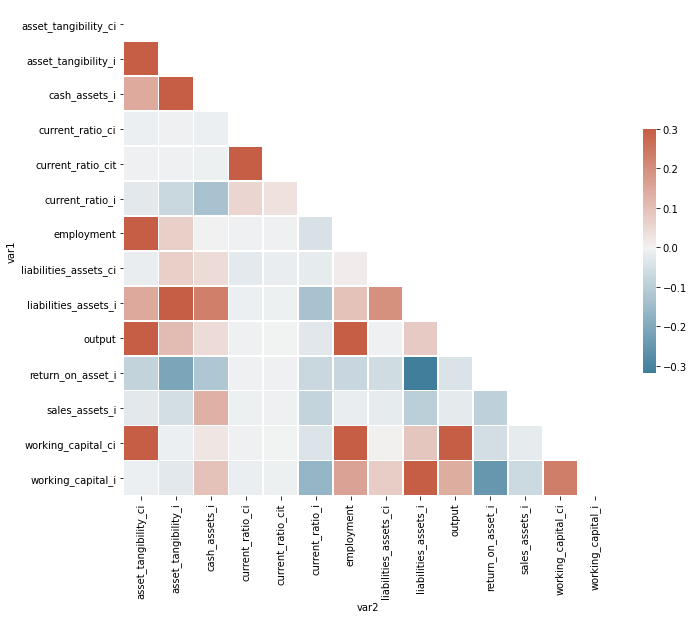

## Scatterplot

From the correlation plot above, pick up a $y$ variables.

We only plot the variables that succeed the Anova test, minus the $y$ var.

Besides, to avoid loading all the table, we have implemented the following rule:

if the size of the table is above >150K rows, then we randomly load 150K rows

First of all, you need to define the Y-axis variables

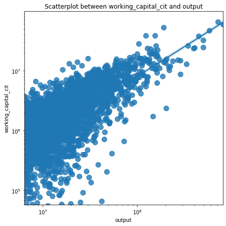

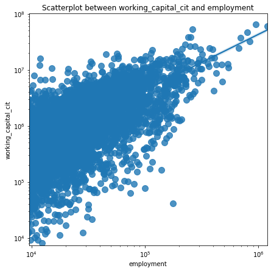

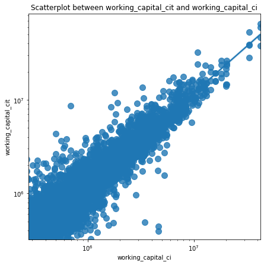

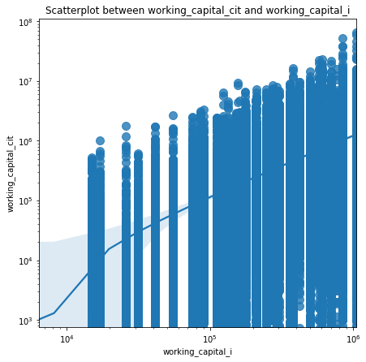

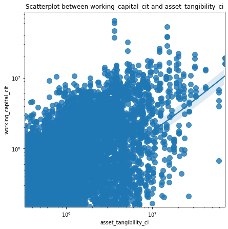

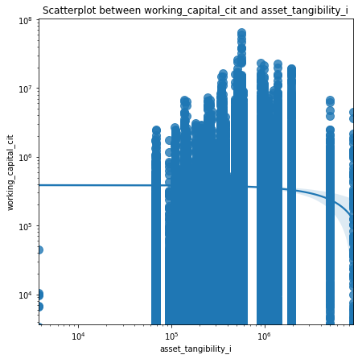

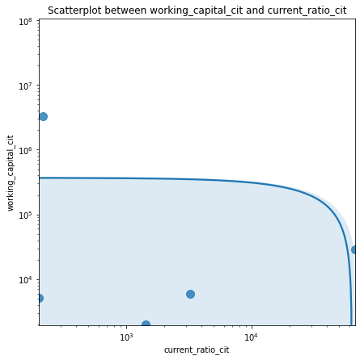

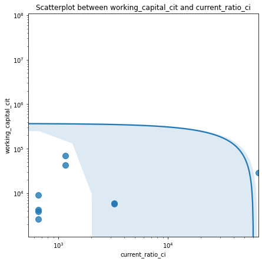

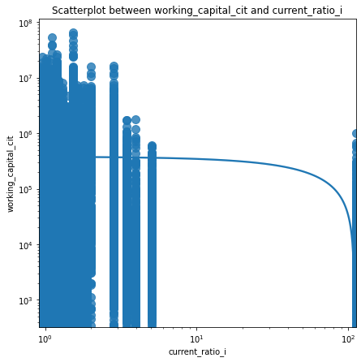

[figure not shown]

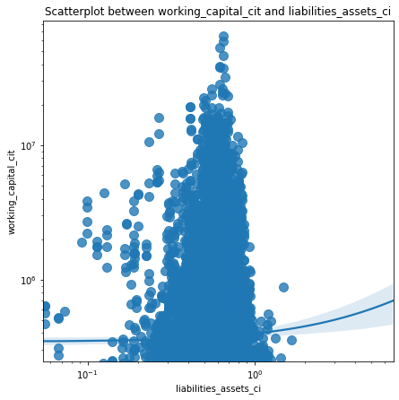

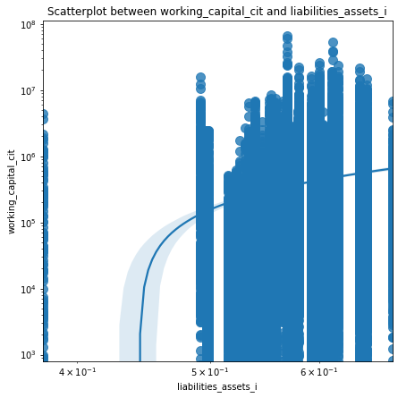

[2 more figures not shown]

### Diverging bars

The diverging bar plot is plotting for the variables to succeed the Anova test

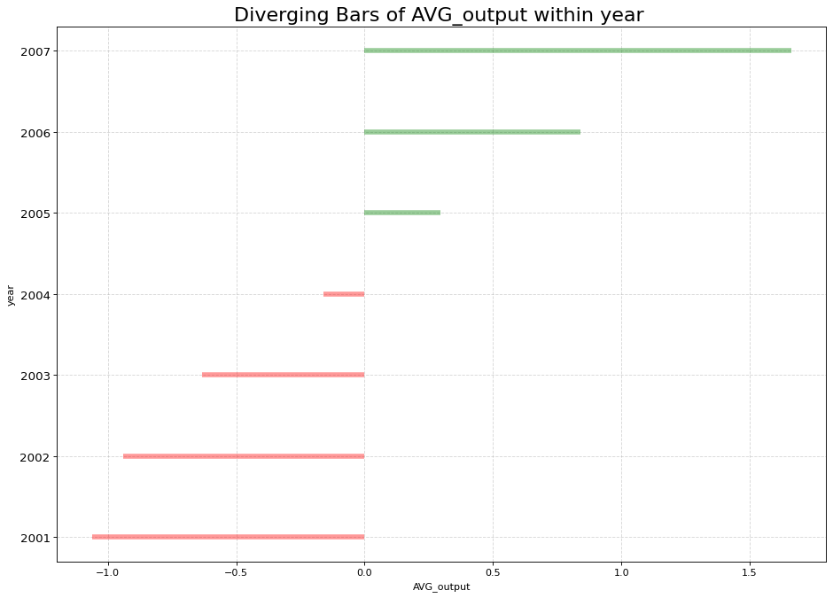

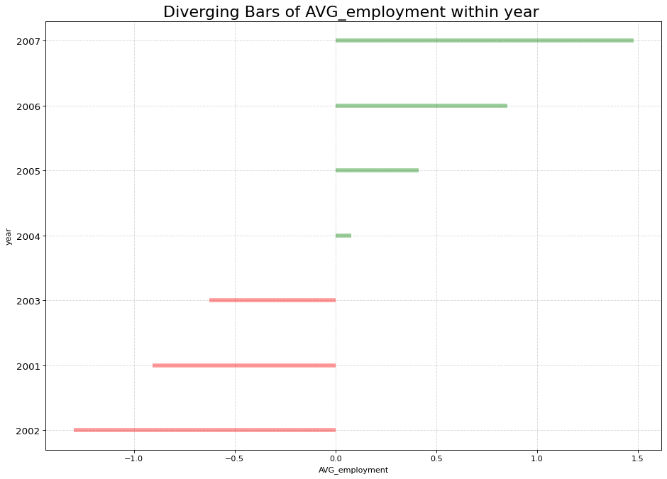

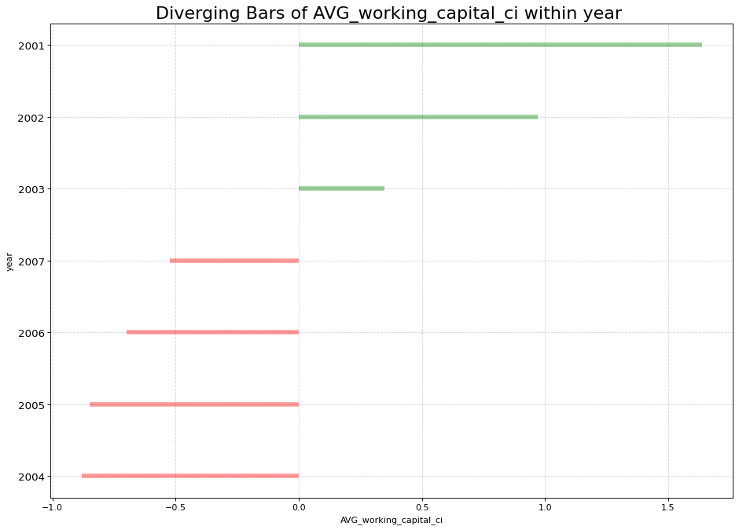

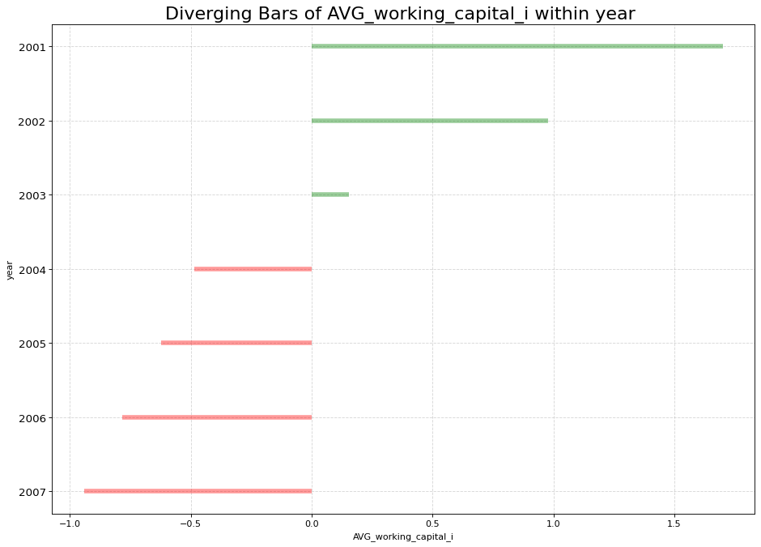

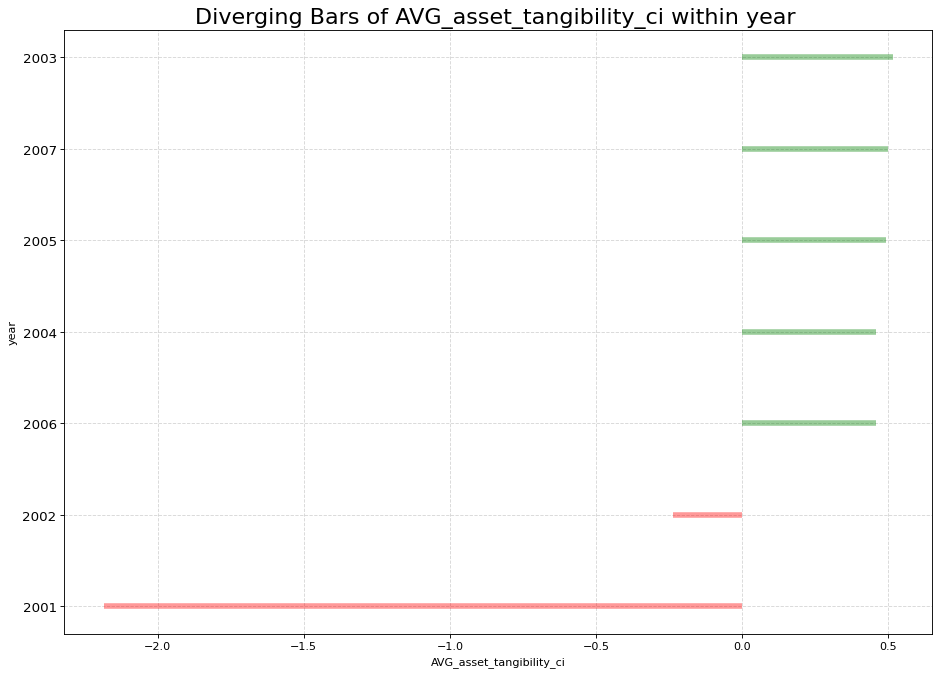

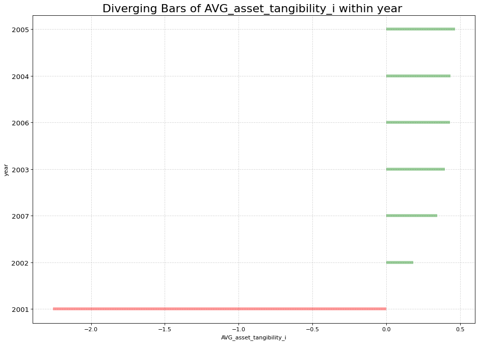

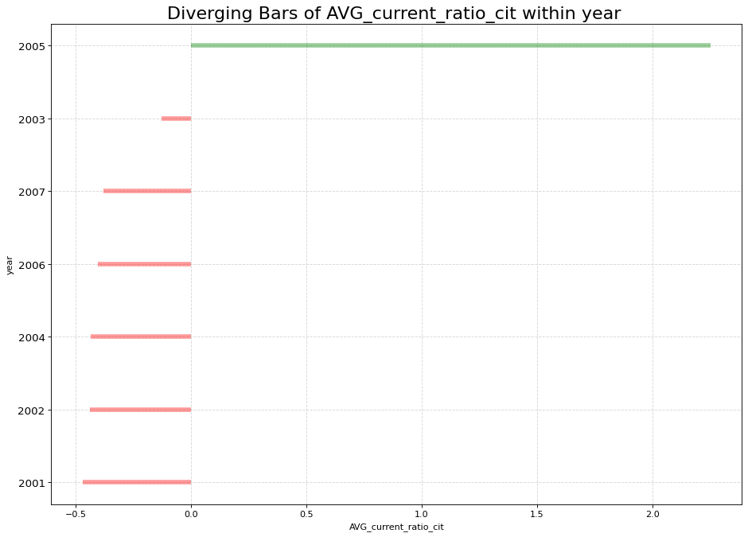

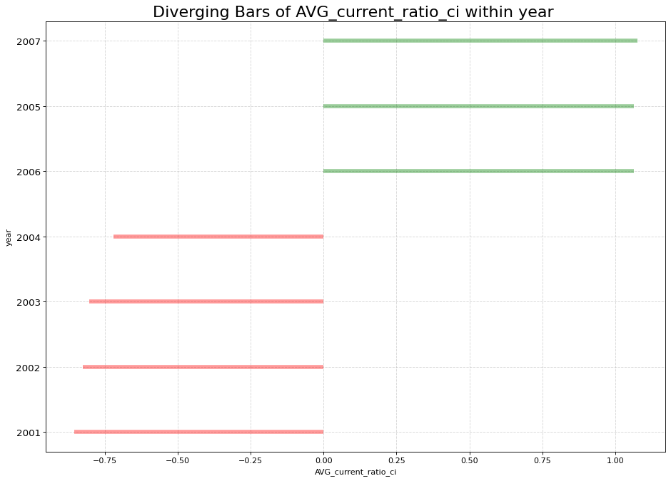

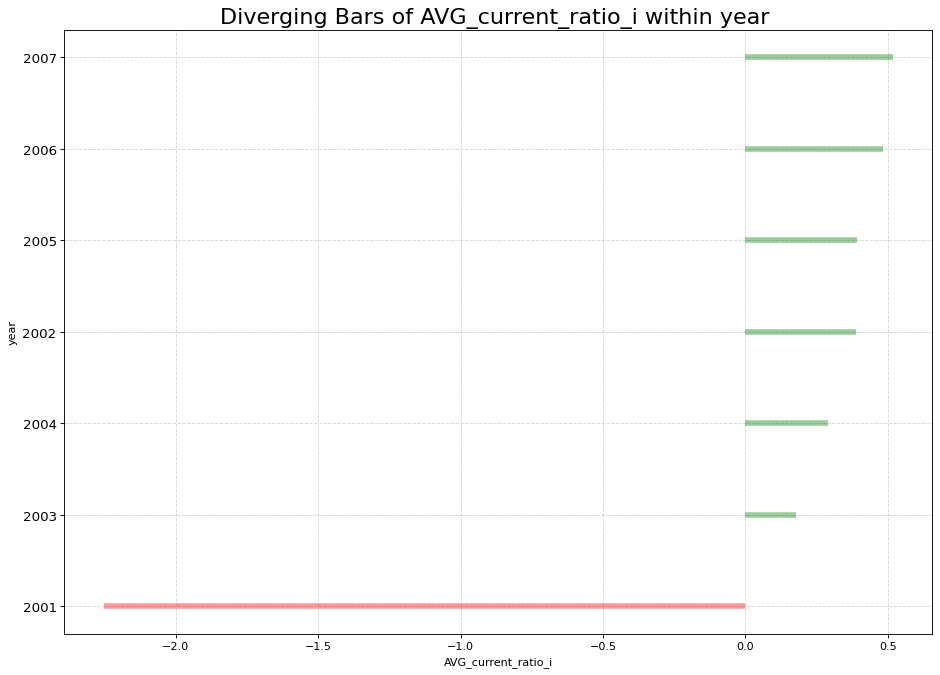

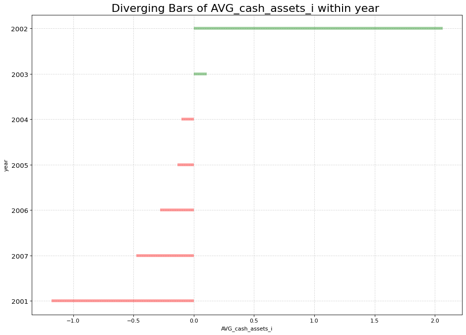

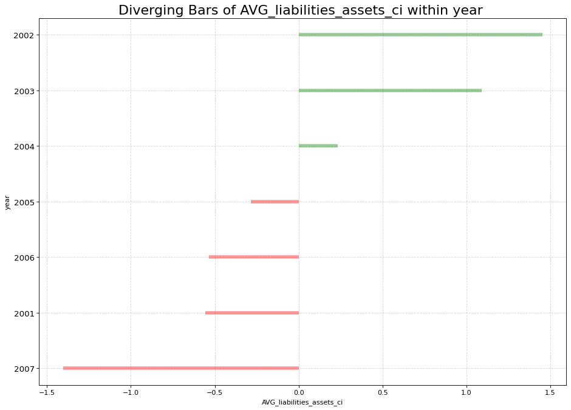

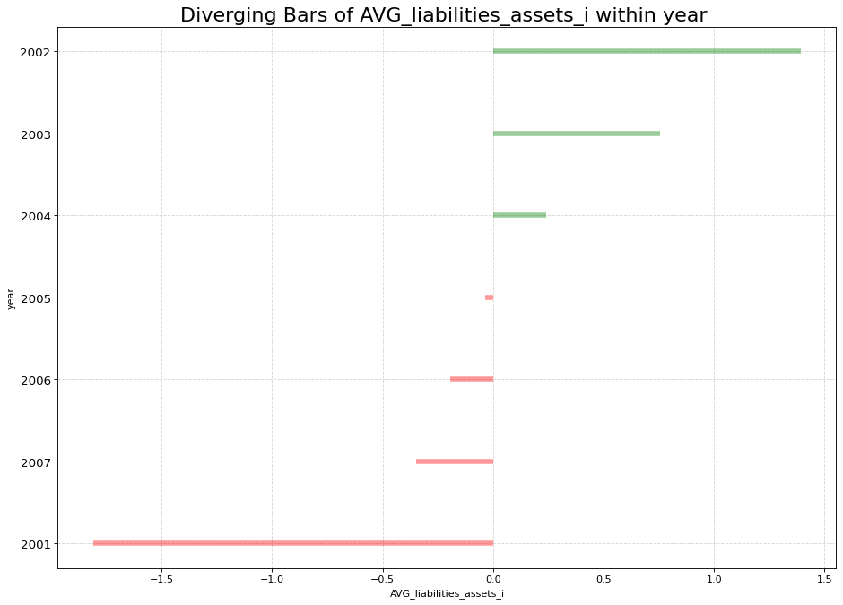

[2 more figures not shown]